International | France | USA

# En France

### Les données

> - Les données utilisées ici sont les données gouvernementales récupérable sur [cette page github](https://github.com/opencovid19-fr/data/tree/master/) (sous-répertoire dist/) ou en téléchargement sur [data.gouv.fr](https://www.data.gouv.fr/fr/datasets/chiffres-cles-concernant-lepidemie-de-covid19-en-france/).
> - Elles-mêmes proviennent (si j'ai bien compris ?) de [Santé Publique France](https://geodes.santepubliquefrance.fr/#c=news) qui les exploite [ici](https://geodes.santepubliquefrance.fr/) (indicateur : Covid-19), voir aussi le [site du gouvernement](https://www.gouvernement.fr/info-coronavirus/carte-et-donnees).

> *Remarque.* Concernant la question de savoir si les données tiennent compte de "tous" les décès liés au Covid-19, ce [post de Baptiste Coulmont](http://coulmont.com/blog/2020/04/24/2020-une-mortalite-specifique/) comparant les données utilisées ici à la surmortalité (2020 vs moyenne 2001-2019, données de l'INSEE) va dans ce sens. Et même si les dernières données sont reventilées a posteriori, il semble que l'ordre de magnitude soit le bon.

```
Les 2 derniers jours :
```

|  | date | deces | deces_ehpad | reanimation | hospitalises | deces_total | deces_e_renorm | deces_total_renorm |
| --- | --- | --- | --- | --- | --- | --- | --- | --- |
| 10389 | 2020-05-16 | 17412.0 | 10213.0 | 2132.0 | 19432.0 | 27625.0 | 10609.0 | 28021.0 |
| 10510 | 2020-05-17 | 17466.0 | 10642.0 | 2087.0 | 19361.0 | 28108.0 | 10642.0 | 28108.0 |

### Les graphes

*Remarque sur la normalisation.* L'hypothèse (probablement fausse) retenue ici est que le pourcentage *quotidien* de décès en ehpad (par rapport au nombre total de décès en ehpad) est le même que celui des décès à l'hôpital (par rapport au nombre de décès total à l'hôpital).

En abscisses, le nombre de jours depuis le 3 mars ("jour 0").

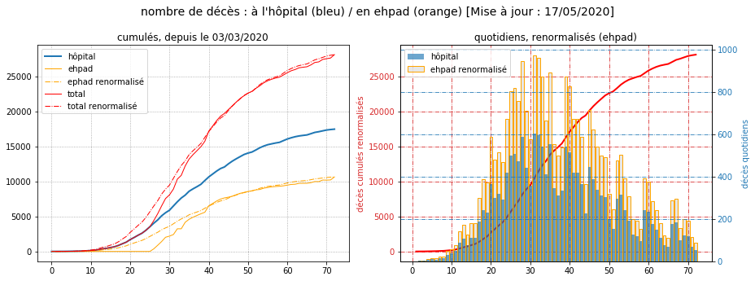

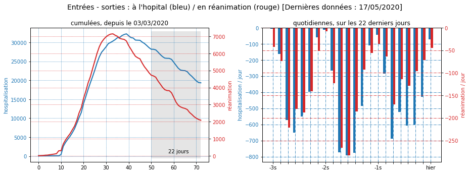

*Remarque.* La proportion de décès hors-hôpital par rapport au nombre de décès total est

```
37.9% au 17/05
```

International < France > USA